# Stat 579 - Homework #6 - Section B

10/8/2019

## Flying etiquette

FiveThirtyEight is a website founded by Statistician and writer Nate Silver to publish results from opinion poll analysis, politics, economics, and sports blogging. One of the featured articles considers [flying etiquette](https://fivethirtyeight.com/features/airplane-etiquette-recline-seat/). This article is based on data collected by FiveThirtyEight and publicly available on github. Use the code below to read in the data from the survey:

```r
fly <- read.csv("https://raw.githubusercontent.com/fivethirtyeight/data/master/flying-etiquette-survey/flying-etiquette.csv")
library(tidyverse)
```

The following couple of lines of code provide a bit of cleanup of the demographic information by reaordering the levels of the corresponding factor variables. Run this code in your session.

```r
fly$Age <- factor(fly$Age, levels=c("18-29", "30-44", "45-60", "> 60", ""))
fly$Household.Income <- factor(fly$Household.Income, levels = c("$0 - $24,999","$25,000 - $49,999", "$50,000 - $99,999", "$100,000 - $149,999", "150000", ""))
fly$Education <- factor(fly$Education, levels = c("Less than high school degree", "High school degree", "Some college or Associate degree", "Bachelor degree",  "Graduate degree", ""))
```

1. Download the RMarkdown file with these homework instructions to use as a template for your work. Make sure to replace “Your Name” in the YAML with your name.
2. Some people do not travel often by plane. Provide a (visual) breakdown of travel frequency (use variable `How.often.do.you.travel.by.plane.`). Reorder the levels in the variable by travel frequency from least frequent travel to most frequent. Draw a barchart of travel frequency and comment on it. Exclude all respondents who never fly from the remainder of the analysis. How many records does the data set have now?

```r
summary(fly$How.often.do.you.travel.by.plane.)
```

```
## A few times per month  A few times per week             Every day
##                    29                     4                     3
##                 Never  Once a month or less   Once a year or less
##                   166                   205                   633
```

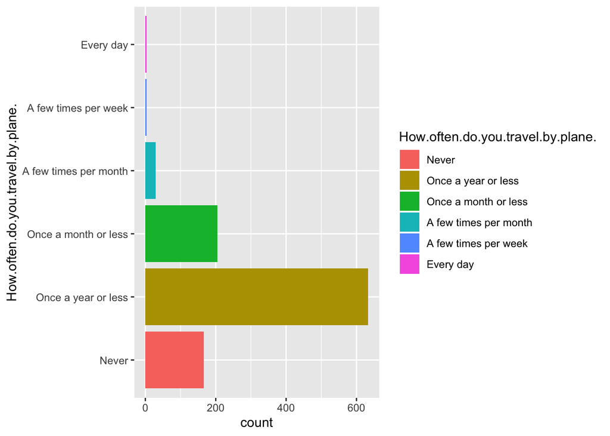

```r
fly$How.often.do.you.travel.by.plane.<- factor(fly$How.often.do.you.travel.by.plane., levels = c("Never", "Once a year or less", "Once a month or less", "A few times per month",  "A few times per week", "Every day"))
fly %>%
ggplot(aes(x=How.often.do.you.travel.by.plane.,fill=How.often.do.you.travel.by.plane.)) +
  geom_bar() +
coord_flip()
```

The bar chart shows that the most people travel once a year or less. Also, there is a negative correlation between how often people travel and the ammount of people that do it.

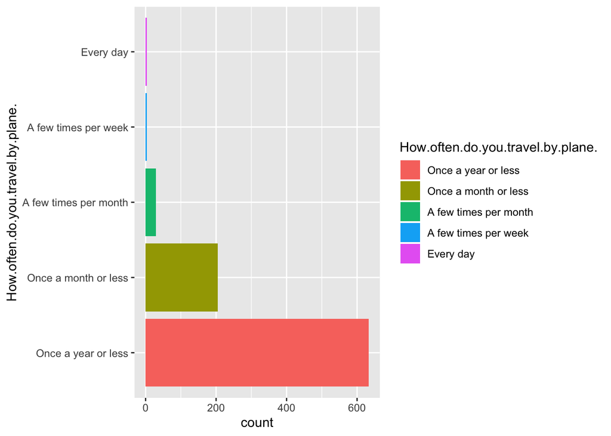

```r
fly = fly %>%
  filter(How.often.do.you.travel.by.plane. =="Once a year or less" | How.often.do.you.travel.by.plane. =="Once a month or less"| How.often.do.you.travel.by.plane. == "A few times per month" | How.often.do.you.travel.by.plane. ==  "A few times per week" | How.often.do.you.travel.by.plane. == "Every day")
fly %>%
ggplot(aes(x=How.often.do.you.travel.by.plane.,fill=How.often.do.you.travel.by.plane.)) +
  geom_bar() +
coord_flip()
```

3. In the demographic variables (`Education`, `Age`, and `Houshold.Income`), replace all occurrences of the empty string "" by a missing value `NA`. How many responses in each variable do not have any missing values? How many responses have no missing values in any of the three variables? (Hint: think of the function `is.na`)

```r
fly <- fly %>% mutate(
Education = replace(Education, Education =="", NA),
Age = replace(Age, Age =="", NA),
Household.Income = replace(Household.Income, Household.Income =="", NA)
)


sum(!is.na(fly$Education))
```

```
## [1] 837
```

```r
sum(!is.na(fly$Age))
```

```
## [1] 843
```

```r
sum(!is.na(fly$Household.Income))
```

```
## [1] 698
```

```r
sum(!is.na(fly$Education)&!is.na(fly$Age)&!is.na(fly$Household.Income))
```

```
## [1] 696
```

There are 837 observations with no missing values in Education, 843 in Age and 698 in Houshold.Income. Overall, there are 696 observations that are not missing any value for all three of the variables.

4. Run the command below and interpret the output. What potential purpose can you see for the chart? What might be a problem with the chart? Find at least one purpose and one problem.

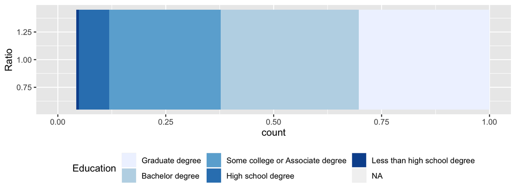

```r
library(ggplot2)
fly$Education = with(fly, factor(Education, levels = rev(levels(Education))))

ggplot(data = fly, aes(x = 1)) +
  geom_bar(aes(fill=Education), position="fill") +
  coord_flip() +
  theme(legend.position="bottom") +
  scale_fill_brewer() +
  xlab("Ratio")
```

5. Rename the variable `In.general..is.itrude.to.bring.a.baby.on.a.plane.` to `baby.on.plane.`. How many levels does the variable `baby.on.plane` have, and what are these levels? Rename the level labeled "" to “Not answered”. Bring the levels of `baby.on.plane` in an order from least rude to most rude. Put the level “Not answered” last. Draw a barchart of variable `baby.on.plane`. Interpret the result. (This question is very similar to question 2, but preps the data for the next question)

```r
colnames(fly)[colnames(fly)=="In.general..is.itrude.to.bring.a.baby.on.a.plane."] <- "baby.on.plane."
summary(fly$baby.on.plane.)
```

```
##                     No, not at all rude  Yes, somewhat rude
##                  25                 592                 182
##      Yes, very rude
##                  75
```

```r
levels(fly$baby.on.plane.)[1] <-"Not answered"
summary(fly$baby.on.plane.)
```

```
##        Not answered No, not at all rude  Yes, somewhat rude
##                  25                 592                 182
##      Yes, very rude
##                  75
```

```r
fly$baby.on.plane.<- factor(fly$baby.on.plane., levels = c("No, not at all rude", "Yes, somewhat rude", "Yes, very rude", "Not answered"))

summary(fly$baby.on.plane.)
```

```
## No, not at all rude  Yes, somewhat rude      Yes, very rude
##                 592                 182                  75
##        Not answered
##                  25
```

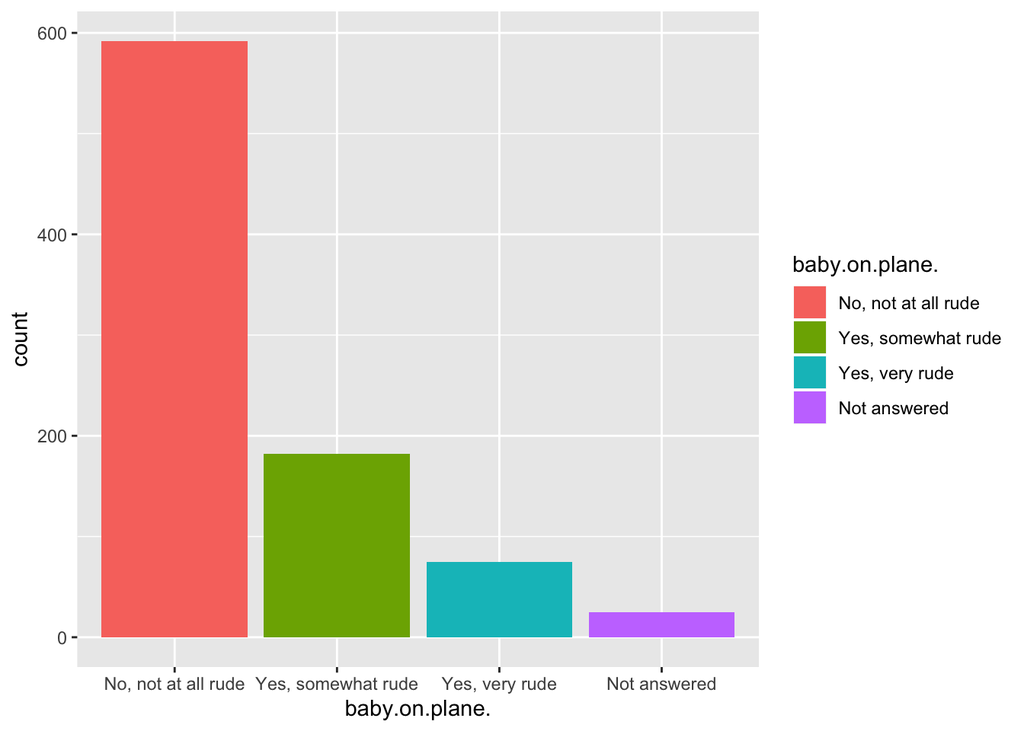

```r
fly %>%
ggplot(aes(x=baby.on.plane., fill = baby.on.plane.)) +
  geom_bar()
```

The vast majority of people that answered find that flying with a baby is not rude at all.

6. Investigate the relationship between gender and the variables `Do.you.have.any.children.under.18.` and `baby.on.plane`. How is the attitude towards babies on planes shaped by gender and own children under 18? Find a plot that summarises your findings (use `ggplot2`).

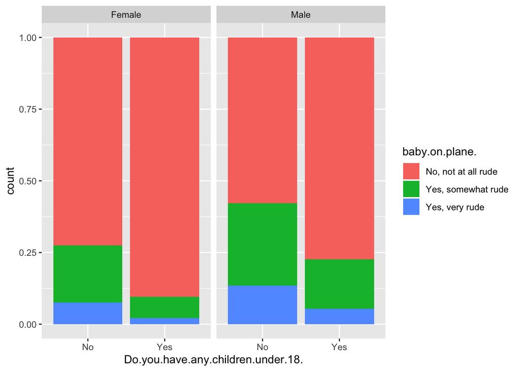

```r
fly = fly %>%
  filter(Do.you.have.any.children.under.18. =="Yes" | Do.you.have.any.children.under.18. =="No") %>%
  filter(Gender =="Male" | Gender =="Female")

fly%>%
  ggplot(aes(x = Do.you.have.any.children.under.18., fill=baby.on.plane.)) + geom_bar(position = "fill") + facet_grid(~Gender)
```

In general, people with kids under 18 are more receptive to babies in planes. When focusing on gender differences, females overall tend to be more receptive to babies in planes.

Due date: the homework is due a week from now on Tuesday For the submission: submit your solution in an R Markdown file and (just for insurance) submit the corresponding html/word file with it.